# Regra e taylor

Rodrigo Ferreira Costa Pinto

2024-03-05

## Introducao

No Brasil, adotamos o sistema de metas de inflação para fazer as nossas políticas monetárias desde 1999, essa meta é definida pelo Conselho Monetário Nacional (CMN) e cabe ao Banco Central (BC) adotar as medidas necessárias para alcançá-la. No sistema atual, O CMN define em junho a inflação meta para três anos à frente e a cada 45 dias o Comitê de Política Monetária (Copom) se reúne para tomar decisões política monetária do país e definir a taxa Selic.

Durante os seis primeiros anos da adoção do sistema de metas de inflação (1999-2004), o Banco Central enfrentou dificuldades para alcançar as metas estabelecidas, principalmente devido às altas taxas de juros adotadas na política monetária. No período de 2005 a 2009, a economia brasileira conseguiu atingir as metas de forma mais fácil, exceto em 2008, quando, devido à intensa crise global, o Banco Central empregou medidas de curto prazo para manter a taxa de inflação estável. Entre 2010 e 2013, a taxa de inflação permaneceu persistentemente próxima ao teto da meta, ou seja, entre 5,9% e 6,5%. É importante ressaltar que nos anos de 2001, 2002 e 2003, as metas de inflação não foram cumpridas, devido à forte desvalorização do câmbio em 2001 (20,3%) e 2002 (53,5%), o que gerou um efeito inercial em 2003, impactando diretamente nos preços de itens administrados, como energia elétrica e telefonia. Contudo, a partir de 2005, a taxa de inflação começou a diminuir, aproximando-se do centro da meta estabelecida, em virtude dos efeitos positivos das políticas cambiais da época sobre os preços internos.(PAULA e SARAIVA, 2015, p. 28-29).

Nesse trabalho vai ser analisado o período entre 2003 e 2023 no Brasil e tendo como base o paper desenvolvido por Taylor em 1993. No seu trabalho, Taylor fez uma função analisando o comportamento da taxa de juros nos Estados Unidos da América, relacionando os juros com a inflação.

\[ i_t = r^* + \pi_t + 0,5(\pi_t - \pi^*) + 0,5(y_t - y^*) \]

Onde:

- \( i_t \) é a taxa de juros nominal definida pelo banco central;
- \( r^* \) é a taxa de juros real de equilíbrio de longo prazo; - \( \pi_t \) é a taxa de inflação atual;
- \( \pi^* \) é a meta de inflação;
- \( y_t \) é o produto interno bruto (PIB) atual; - \( y^* \) é o produto potencial.

## Objetivo

\[ i = \beta_0 + \beta_1 (\pi - \pi_e) + \beta_2 (Y - Y_p) + \beta_3 i_{t-1} + \beta_4 i_{t-2} + \nu \]

Onde:

- - \( (\pi - \pi_e) \) representa o desvio da inflação em relação à sua meta;
- - \( (Y - Y_p) \) é o hiato do produto;
- - \( i_{t-1} \) é a taxa de juros do período anterior;
- - \( i_{t-2} \) é a taxa de juros do período anterior ao anterior.

## Metodologia

Os dados usados nesse trabalho foram coletados no site do BCB timed series e foram transformado em log usando logaritmo natural.

### Deflacionar

A serie foi deflacionada usando essa formula:

\[ S_{\text{deflacionada}} = \frac{S_{\text{nominal}}}{\text{Índice de Deflator}} \]

Onde:

- - \( S_{\text{deflacionada}} \) é a série deflacionada (ajustada para remover o efeito da inflação).
- - \( S_{\text{nominal}} \) é a série nominal (sem ajuste para inflação).
- - \( \text{Índice de Deflator} \) é o índice que representa a variação dos preços ao longo do tempo.

### Hiato

Para calcular o hiato foi usado o Hodrick-Prescottn hp filter  
\[ \text{Minimizar } \sum_{t=1}^{T} \left[ (y_t - \bar{y}_t)^2 + \lambda(\Delta^2 y_t)^2 \right] \]

Onde:

- - \( y_t \) é o valor observado da série temporal no tempo \( t \).
- - \( \bar{y}_t \) é a tendência de longo prazo (componente de tendência) no tempo \( t \).
- - \( \Delta^2 y_t \) é a variação quadrática da série temporal no tempo \( t \).
- - \( \lambda \) é o parâmetro de suavização, que controla o grau de suavização do componente cíclico em relação ao componente de tendência. Quanto maior o valor de \( \lambda \), mais suavizado será o componente cíclico.

  O objetivo do filtro HP é encontrar a tendência de longo prazo (\( \bar{y}_t \)) que minimize a soma ponderada dos desvios quadráticos entre os valores observados da série temporal e a tendência, juntamente com a variação quadrática da série temporal. Isso ajuda a separar o componente cíclico (variações de curto prazo) do componente de tendência (variação de longo prazo) da série temporal.

### Testes

#### Heterocedasticidade

Heterocedasticidade refere-se à situação em que a variância dos erros de um modelo estatístico não é constante ao longo do tempo ou em diferentes níveis das variáveis independentes.

- Goldfeld-Quandt.
- Breusch-Pagan.
- O teste de White

#### Autocorrelação

Autocorrelação é quando existe uma relacao entre os erros em uma observacao e os erros em observacoes anteriores.

- Durbin-Watson
- Teste ARCH
- Box-Pierce

#### Multicolinearidade

multicolinearidade existe quando duas ou mais variaveis independentes sao altamente correlacionadas, tornando dificil isolar seus efeitos individuais na variavel dependente

- BOX

## Estimacao dos modelos

### Modelo entre 2003 e 2023

```r
summary(`modelo_2003-02-01_até_2023-12-01`)
```

```
##
## Time series regression with "numeric" data:
## Start = 1, End = 249
##
## Call:
## dynlm(formula = formula, data = dados_filtrados)
##
## Residuals:
##       Min        1Q    Median        3Q       Max
## -0.102131 -0.008329  0.000308  0.008198  0.160437
##
## Coefficients:
##                 Estimate Std. Error t value Pr(>|t|)
## (Intercept)   -0.0006854  0.0017406  -0.394   0.6941
## desvio        -0.0049553  0.0029044  -1.706   0.0893 .
## hiato          0.0020687  0.0030570   0.677   0.4992
## lag(selic, 1)  0.6751391  0.0628036  10.750   <2e-16 ***
## lag(selic, 2)  0.1862212  0.0627420   2.968   0.0033 **
## ---
## Signif. codes:  0 '***' 0.001 '**' 0.01 '*' 0.05 '.' 0.1 ' ' 1
##
## Residual standard error: 0.02741 on 244 degrees of freedom
##   (2 observations deleted due to missingness)
## Multiple R-squared:  0.7097, Adjusted R-squared:  0.7049
## F-statistic: 149.1 on 4 and 244 DF,  p-value: < 2.2e-16
```

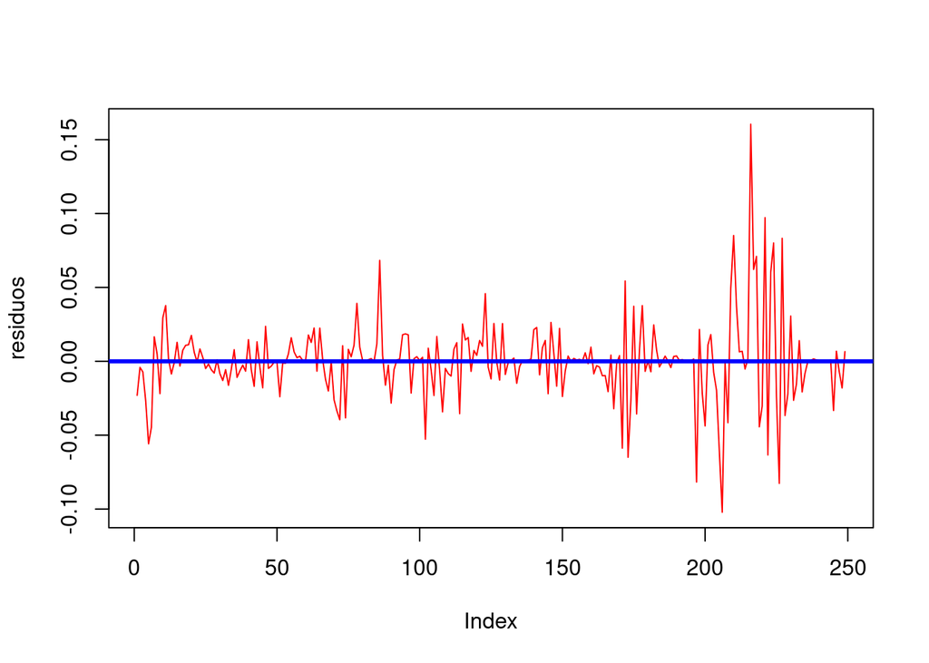

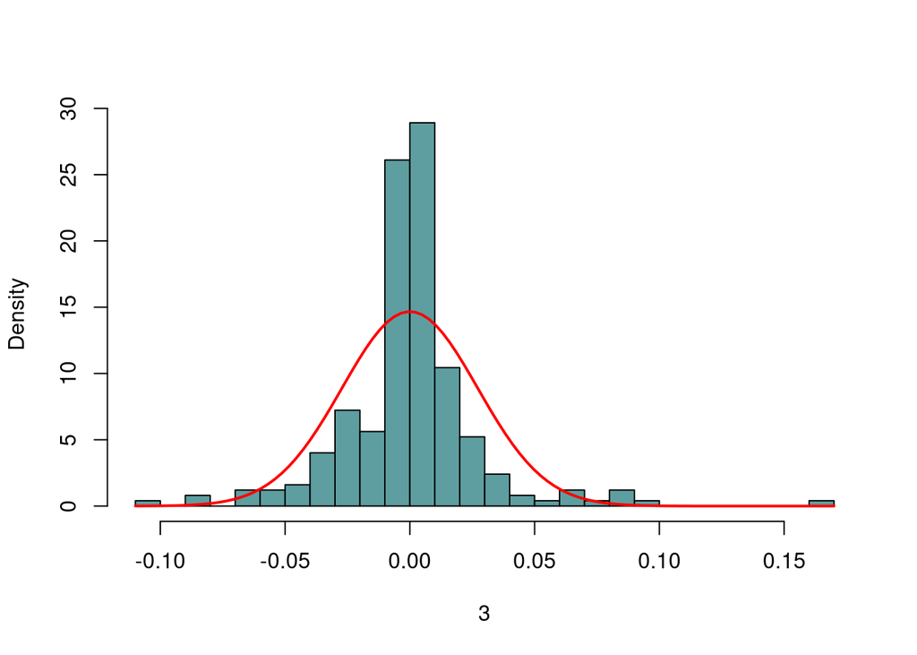

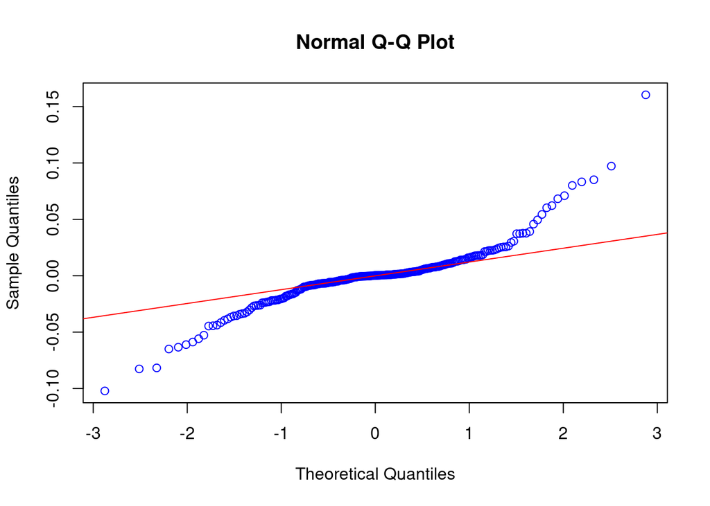

[output not shown]

[output cut: 151 more lines]

```
## $Box.test
##
##  Box-Pierce test
##
## data:  residuos
## X-squared = 46.674, df = 12, p-value = 5.309e-06
##
##
## $adf
##
##  Augmented Dickey-Fuller Test
##
## data:  residuos
## Dickey-Fuller = -4.3891, Lag order = 6, p-value = 0.01
## alternative hypothesis: stationary
```

```r
analisar_modelo(`modelo_2003-02-01_até_2023-12-01`)
```

### Modelo entre 2003 e 2010

```r
summary(`modelo_2003-02-01_até_2010-12-01`)
```

```
##
## Time series regression with "numeric" data:
## Start = 1, End = 93
##
## Call:
## dynlm(formula = formula, data = dados_filtrados)
##
## Residuals:
##       Min        1Q    Median        3Q       Max
## -0.050287 -0.007950  0.000261  0.007651  0.066887
##
## Coefficients:
##                Estimate Std. Error t value Pr(>|t|)
## (Intercept)   -0.002043   0.001894  -1.079    0.284
## desvio        -0.005582   0.006026  -0.926    0.357
## hiato          0.004978   0.013153   0.378    0.706
## lag(selic, 1)  0.911898   0.106985   8.524 3.92e-13 ***
## lag(selic, 2) -0.095711   0.105601  -0.906    0.367
## ---
## Signif. codes:  0 '***' 0.001 '**' 0.01 '*' 0.05 '.' 0.1 ' ' 1
##
## Residual standard error: 0.01735 on 88 degrees of freedom
##   (2 observations deleted due to missingness)
## Multiple R-squared:  0.721,  Adjusted R-squared:  0.7083
## F-statistic: 56.86 on 4 and 88 DF,  p-value: < 2.2e-16
```

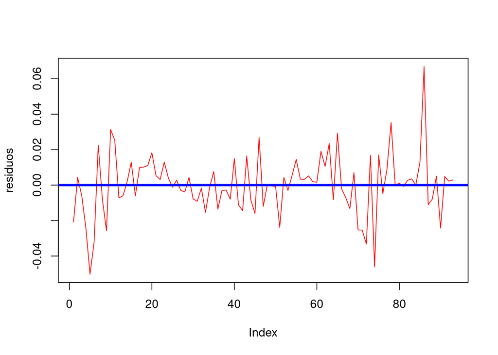

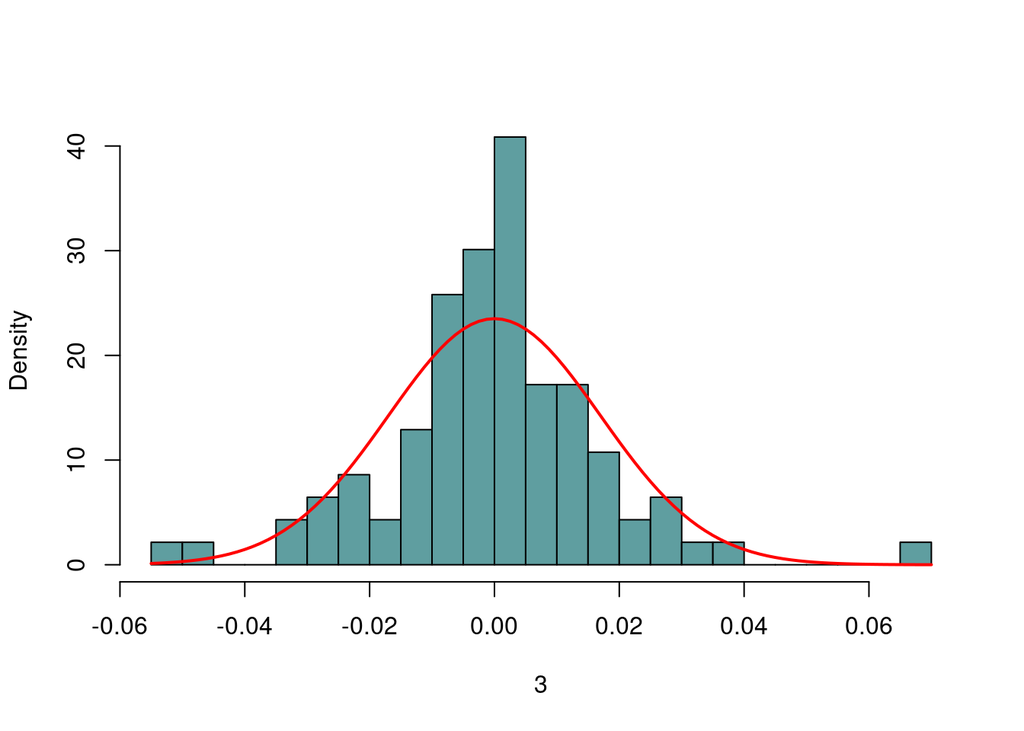

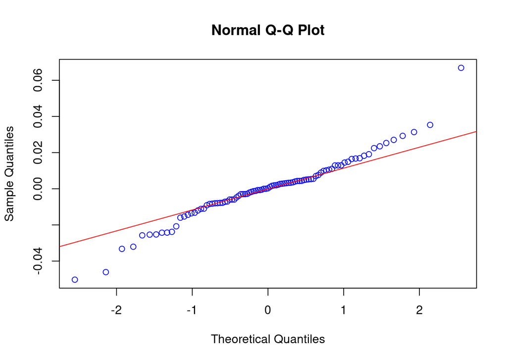

[output not shown]

[output cut: 89 more lines]

```
## $Box.test
##
##  Box-Pierce test
##
## data:  residuos
## X-squared = 12.702, df = 12, p-value = 0.3911
##
##
## $adf
##
##  Augmented Dickey-Fuller Test
##
## data:  residuos
## Dickey-Fuller = -4.324, Lag order = 4, p-value = 0.01
## alternative hypothesis: stationary
```

```r
analisar_modelo(`modelo_2003-02-01_até_2010-12-01`)
```

### Modelo entre 2011 e 2016

```r
summary(`modelo_2011-01-01_até_2016-05-01`)
```

```
##
## Time series regression with "numeric" data:
## Start = 1, End = 63
##
## Call:
## dynlm(formula = formula, data = dados_filtrados)
##
## Residuals:
##       Min        1Q    Median        3Q       Max
## -0.053470 -0.006782  0.000539  0.009614  0.045701
##
## Coefficients:
##                Estimate Std. Error t value Pr(>|t|)
## (Intercept)   0.0001326  0.0022005   0.060   0.9521
## desvio        0.0063158  0.0101185   0.624   0.5350
## hiato         0.0009262  0.0074413   0.124   0.9014
## lag(selic, 1) 0.5577142  0.1245798   4.477  3.6e-05 ***
## lag(selic, 2) 0.2959373  0.1244168   2.379   0.0207 *
## ---
## Signif. codes:  0 '***' 0.001 '**' 0.01 '*' 0.05 '.' 0.1 ' ' 1
##
## Residual standard error: 0.01672 on 58 degrees of freedom
##   (2 observations deleted due to missingness)
## Multiple R-squared:  0.6729, Adjusted R-squared:  0.6503
## F-statistic: 29.83 on 4 and 58 DF,  p-value: 1.732e-13
```

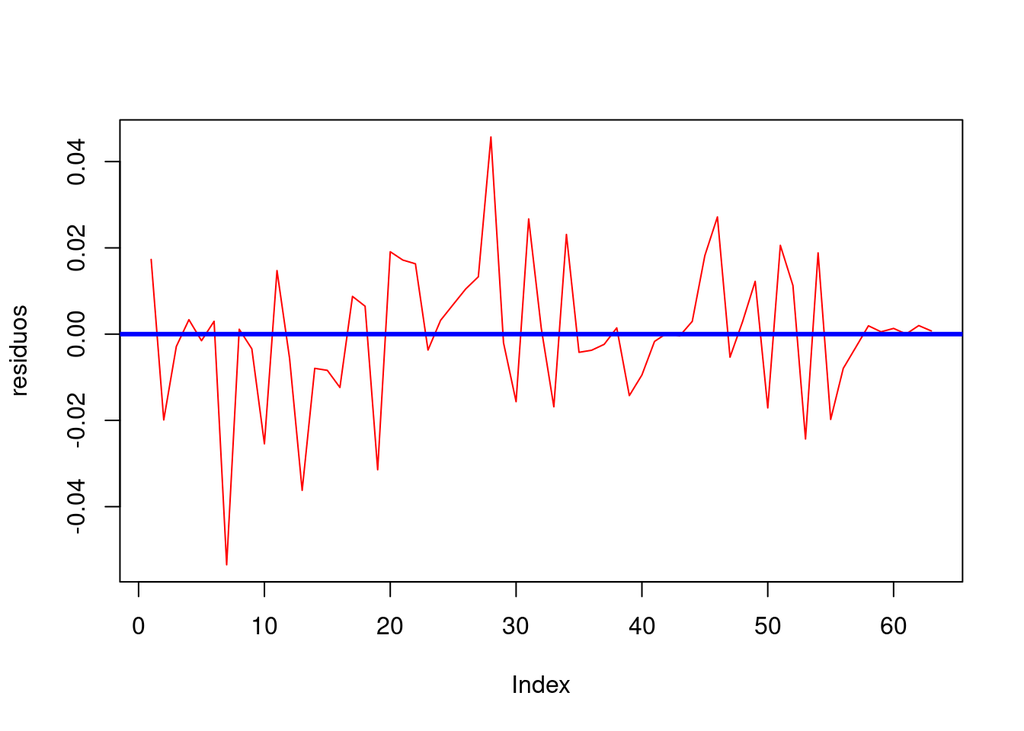

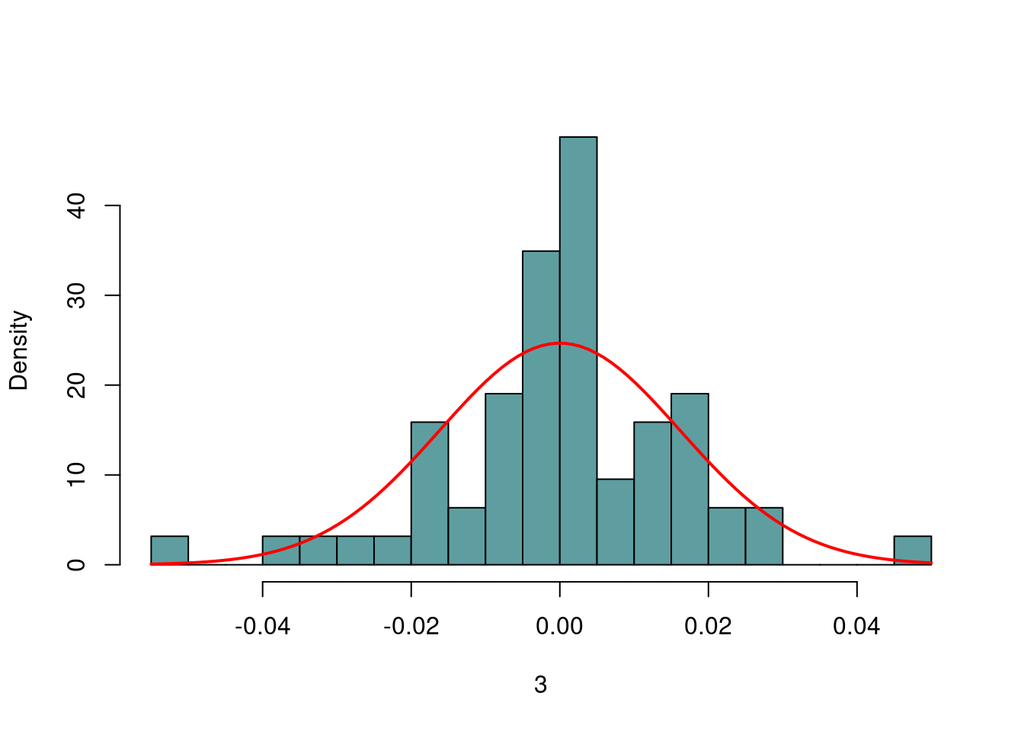

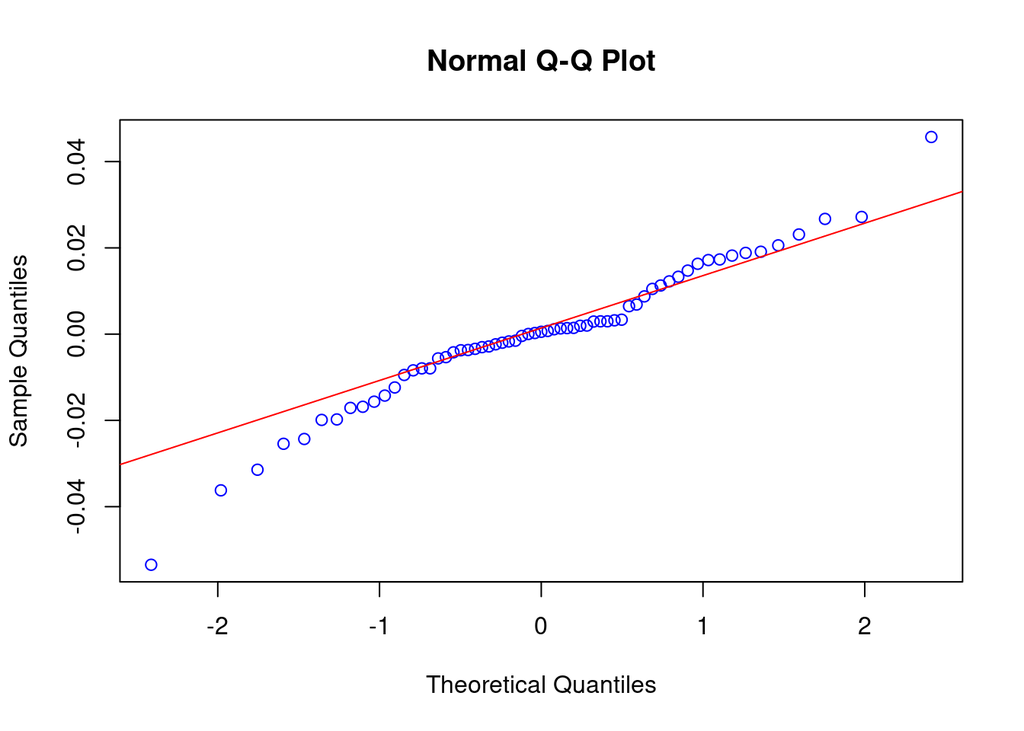

[output not shown]

[output cut: 77 more lines]

```
## $Box.test
##
##  Box-Pierce test
##
## data:  residuos
## X-squared = 16.409, df = 12, p-value = 0.1732
##
##
## $adf
##
##  Augmented Dickey-Fuller Test
##
## data:  residuos
## Dickey-Fuller = -3.0281, Lag order = 3, p-value = 0.1586
## alternative hypothesis: stationary
```

```r
analisar_modelo(`modelo_2011-01-01_até_2016-05-01`)
```

### Modelo entre 2016 e 2018

```r
summary(`modelo_2016-05-01_até_2018-12-01`)
```

```
##
## Time series regression with "numeric" data:
## Start = 1, End = 30
##
## Call:
## dynlm(formula = formula, data = dados_filtrados)
##
## Residuals:
##       Min        1Q    Median        3Q       Max
## -0.053783 -0.005752  0.003081  0.007985  0.045350
##
## Coefficients:
##                 Estimate Std. Error t value Pr(>|t|)
## (Intercept)   -0.0063624  0.0062398  -1.020   0.3177
## desvio        -0.0033740  0.0103190  -0.327   0.7464
## hiato         -0.0003099  0.0033300  -0.093   0.9266
## lag(selic, 1)  0.2851059  0.1813056   1.573   0.1284
## lag(selic, 2)  0.4795175  0.1820797   2.634   0.0143 *
## ---
## Signif. codes:  0 '***' 0.001 '**' 0.01 '*' 0.05 '.' 0.1 ' ' 1
##
## Residual standard error: 0.02401 on 25 degrees of freedom
##   (2 observations deleted due to missingness)
## Multiple R-squared:  0.4622, Adjusted R-squared:  0.3761
## F-statistic: 5.371 on 4 and 25 DF,  p-value: 0.002912
```

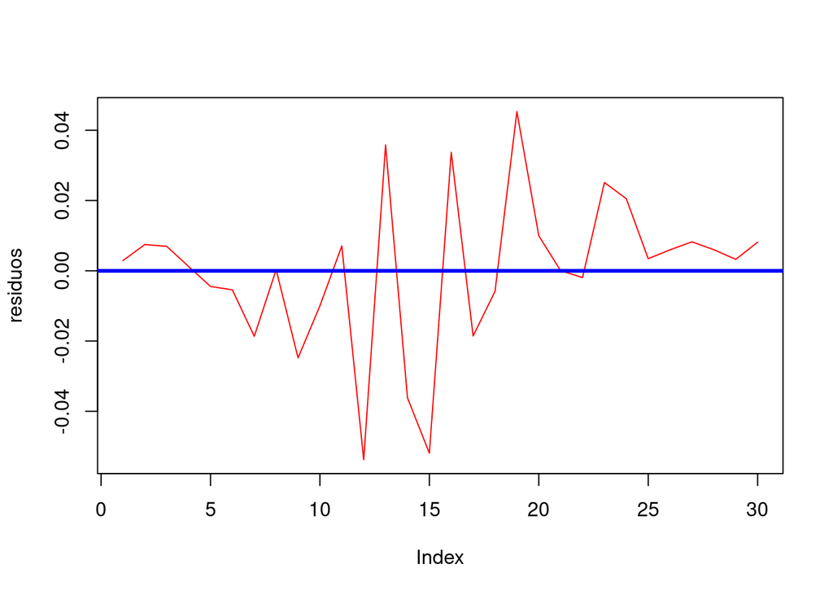

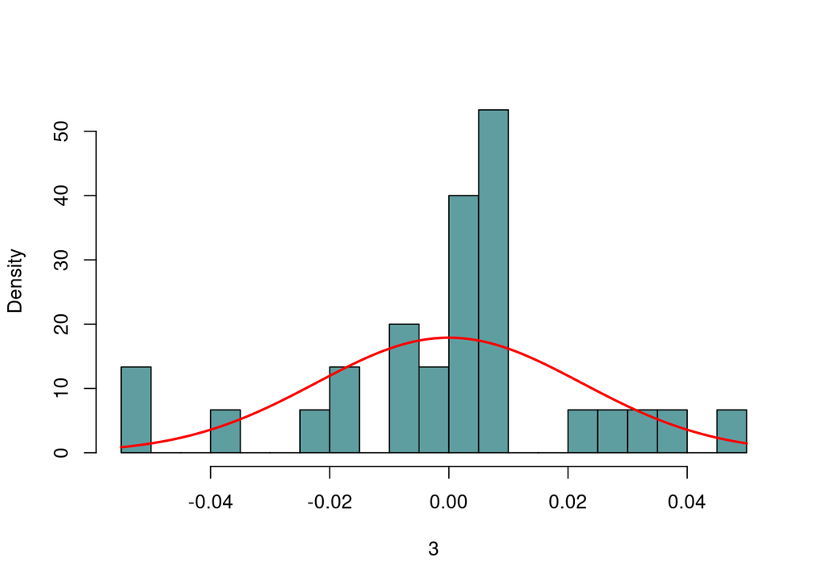

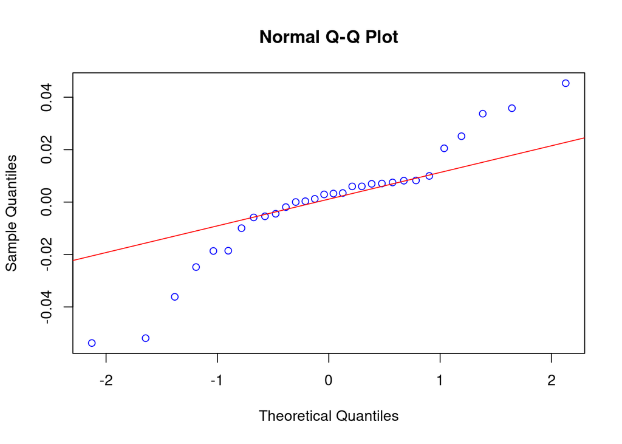

```
## $modelo
##
## Time series regression with "numeric" data:
## Start = 1, End = 30
##
## Call:
## dynlm(formula = formula, data = dados_filtrados)
##
## Coefficients:
##   (Intercept)         desvio          hiato  lag(selic, 1)  lag(selic, 2)
##    -0.0063624     -0.0033740     -0.0003099      0.2851059      0.4795175
##
##
## $residuos
##             3             4             5             6             7
##  2.910256e-03  7.479342e-03  6.955827e-03  1.219378e-03 -4.456761e-03
##             8             9            10            11            12
## -5.437790e-03 -1.865929e-02  3.173413e-04 -2.480215e-02 -9.963309e-03
##            13            14            15            16            17
##  7.079607e-03 -5.378300e-02  3.581584e-02 -3.615736e-02 -5.192846e-02
##            18            19            20            21            22
##  3.371433e-02 -1.856630e-02 -5.856811e-03  4.534954e-02  9.966557e-03
##            23            24            25            26            27
##  1.392943e-05 -1.922783e-03  2.512564e-02  2.051215e-02  3.445801e-03
##            28            29            30            31            32
##  5.980070e-03  8.247866e-03  5.994151e-03  3.252654e-03  8.153724e-03
##
## $jarque_bera
##
## Title:
##  Jarque - Bera Normalality Test
##
## Test Results:
##   STATISTIC:
##     X-squared: 2.0398
##   P VALUE:
##     Asymptotic p Value: 0.3606
##
##
## $shapiro
```

[output cut: 63 more lines]

```
## $Box.test
##
##  Box-Pierce test
##
## data:  residuos
## X-squared = 15.319, df = 12, p-value = 0.2245
##
##
## $adf
##
##  Augmented Dickey-Fuller Test
##
## data:  residuos
## Dickey-Fuller = -2.3862, Lag order = 3, p-value = 0.4243
## alternative hypothesis: stationary
```

```r
analisar_modelo(`modelo_2016-05-01_até_2018-12-01`)
```

### Modelo entre 2019 e 2022

```r
summary(`modelo_2019-01-01_até_2022-12-01`)
```

```
##
## Time series regression with "numeric" data:
## Start = 1, End = 46
##
## Call:
## dynlm(formula = formula, data = dados_filtrados)
##
## Residuals:
##       Min        1Q    Median        3Q       Max
## -0.100605 -0.027803 -0.002902  0.024287  0.150892
##
## Coefficients:
##                Estimate Std. Error t value Pr(>|t|)
## (Intercept)    0.002453   0.007956   0.308    0.759
## desvio        -0.005752   0.006273  -0.917    0.364
## hiato          0.010302   0.012677   0.813    0.421
## lag(selic, 1)  0.688753   0.152178   4.526 5.08e-05 ***
## lag(selic, 2)  0.165494   0.151587   1.092    0.281
## ---
## Signif. codes:  0 '***' 0.001 '**' 0.01 '*' 0.05 '.' 0.1 ' ' 1
##
## Residual standard error: 0.05308 on 41 degrees of freedom
##   (2 observations deleted due to missingness)
## Multiple R-squared:  0.7212, Adjusted R-squared:  0.694
## F-statistic: 26.52 on 4 and 41 DF,  p-value: 6.696e-11
```

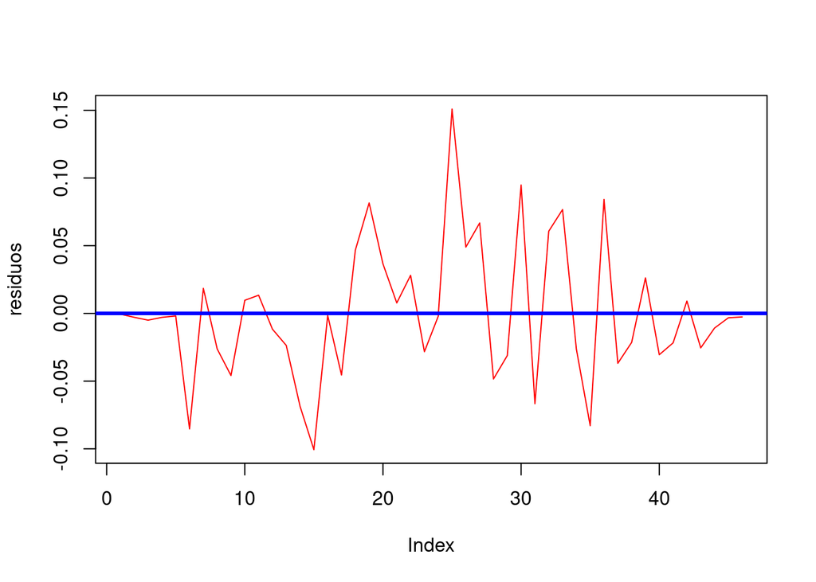

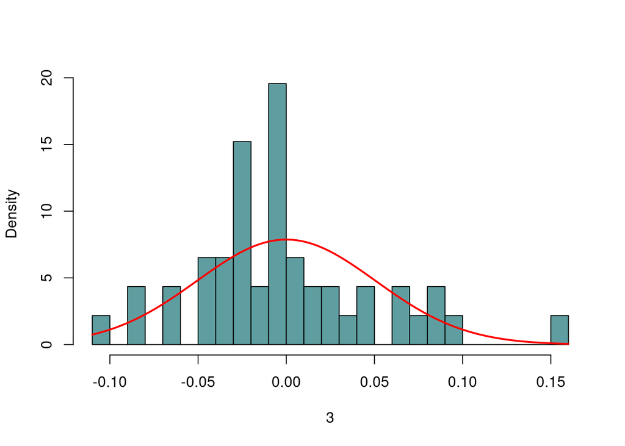

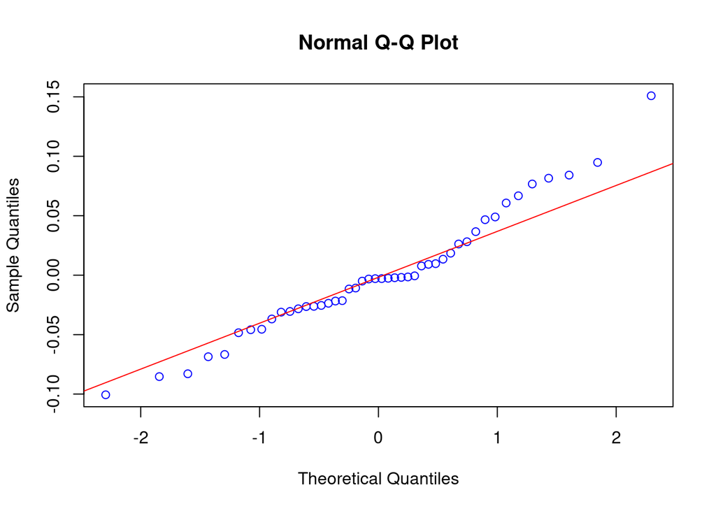

```
## $modelo
##
## Time series regression with "numeric" data:
## Start = 1, End = 46
##
## Call:
## dynlm(formula = formula, data = dados_filtrados)
##
## Coefficients:
##   (Intercept)         desvio          hiato  lag(selic, 1)  lag(selic, 2)
##      0.002453      -0.005752       0.010302       0.688753       0.165494
##
##
## $residuos
##             3             4             5             6             7
## -0.0005673018 -0.0028859406 -0.0049879124 -0.0029173827 -0.0018828039
##             8             9            10            11            12
## -0.0853091196  0.0185063056 -0.0262077424 -0.0458736770  0.0096899882
##            13            14            15            16            17
##  0.0134409607 -0.0116174548 -0.0236294822 -0.0685980219 -0.1006049620
##            18            19            20            21            22
## -0.0014969189 -0.0454864821  0.0466716314  0.0815614918  0.0365959805
##            23            24            25            26            27
##  0.0077464874  0.0281180213 -0.0282761581 -0.0021433232  0.1508917661
##            28            29            30            31            32
##  0.0489644391  0.0667662207 -0.0484092190 -0.0311110200  0.0948046231
##            33            34            35            36            37
## -0.0666863632  0.0606996300  0.0766888327 -0.0263827286 -0.0829222013
##            38            39            40            41            42
##  0.0841595031 -0.0368434281 -0.0214278866  0.0262139567 -0.0305145304
##            43            44            45            46            47
## -0.0217541755  0.0091159149 -0.0254528336 -0.0108115342 -0.0032378444
##            48
## -0.0025973049
##
## $jarque_bera
##
## Title:
##  Jarque - Bera Normalality Test
##
```

[output cut: 71 more lines]

```
## $Box.test
##
##  Box-Pierce test
##
## data:  residuos
## X-squared = 14.124, df = 12, p-value = 0.2928
##
##
## $adf
##
##  Augmented Dickey-Fuller Test
##
## data:  residuos
## Dickey-Fuller = -3.2252, Lag order = 3, p-value = 0.09493
## alternative hypothesis: stationary
```

```r
analisar_modelo(`modelo_2019-01-01_até_2022-12-01`)
```

## Conclusoes

Foi observado no modelo grande dependencia das variaveis

```
 lag(selic, 1)  lag(selic, 2)
```

## Referencias

GUJARATI, D. N. Econometria Básica. São Paulo: MAKRON Books, 2006.

DE PAULA, L. F.; SARAIVA, P. J. Novo Consenso Macroeconômico e Regime de Metas de Inflação: algumas implicações para o Brasil. [*s. l.*], 2015.

TOLOTTI, R. de L., Rodrigo. O que é e como funciona o regime de metas de inflação? *In*: INFOMONEY. 3 fev. 2023. Disponível em: https://www.infomoney.com.br/economia/o-que-e-e-como-funciona-o-regime-de-metas-de-inflacao/. Acesso em: 1 abr. 2024.